# 浅野ゼミナール 夏合宿 2014

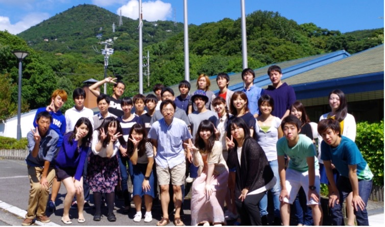

2014年度 浅野ゼミナール夏合宿 参加者30名。於：静岡県伊東市

2014年度浅野ゼミナール夏合宿が、9月12日〜14日の日程で、静岡県伊東市で開催されました。今回の合宿では、一日目に四年生による卒業論文の中間発表と先生によるエニアグラムの講義と性格診断、二日目には三年生による論文の中間発表と一、二年生による「ビブリオバトル」が行われました。今年の夏合宿には、早稲田大学から二名（拓大OGの院生と学部生）、立教大学から一名、合計三名が他大学から参加しました。

四年生にとって夏合宿での中間発表は、卒業論文を仕上げる上で非常に重要な場です。四年生の課題は、初めて論文の内容を聞く人でも理解できるような説明をすることでした。普段、実証分析にふれることのない一、二年生から寄せられるシンプルな質問に対して、できるだけわかりやすく説明することが要求されます。先生からは、論文を完成させるために必要な具体的な課題について、発表者ひとりひとりにアドバイスをいただきました。

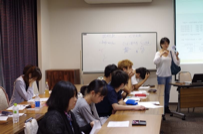

四年卒業論文の中間発表の様子

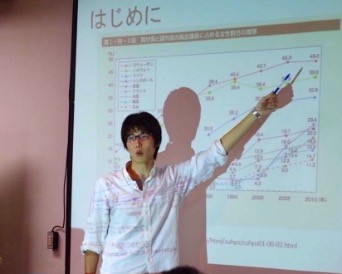

四年卒業論文の中間発表の様子

三年生によるグループ別論文発表は、浅野ゼミナールでは初の試みでした。その目的は二つあり、一つは実際に論文を書くことで実証政治学についての知識を深めること。二つ目は四年の卒業論文作成時に、より完成度の高い論文を仕上げる予行演習のためです。三つのグループに分かれての発表でしたが、どのグループも個性あるテーマで研究を行い、とても良い経験になりました。

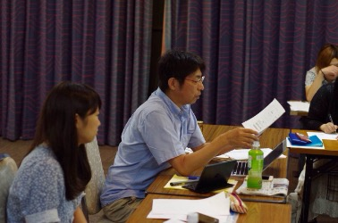

三年論文の中間発表の様子

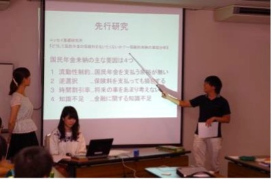

三年論文の中間発表の様子

毎年恒例のビブリオバトルでは、二年生に加えて一年生も参加しました。ビブリオバトルにおいて重要なことは、本の内容をいかにわかりやすく伝え、聞いている人に「自分も読んでみたい」と思ってもらえることです。大勢の人の前で自分の考えを伝えるというプレゼンテーション能力を鍛えることもできます。様々な分野の本の内容を紹介してもらったおかげで、とても有意義な時間を過ごすことができました。

[figure not shown]

ビブリオバトル決勝戦

[figure not shown]

ビブリオバトルのファイナリスト6人

今回の合宿では、ひとりひとりが積極的に参加することで、お互いのインセンティブを刺激しつつ高めることができました。

二日目の夜には、懇親会を行いました。普段あまり関わることのない他学年と接する良い機会となり、交流を深めることができました。ビンゴ大会では、iPodやBluetoothスピーカーなど豪華な景品が用意され、とても盛り上がりました。最終日には、温泉や観光名所を巡り伊豆を観光しました。名物の海鮮丼など食べ物も美味しく、心身ともにリフレッシュすることができました。

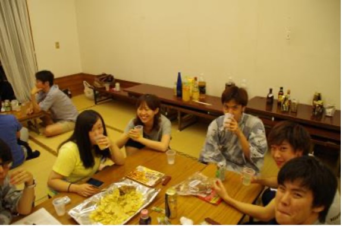

懇親会の様子

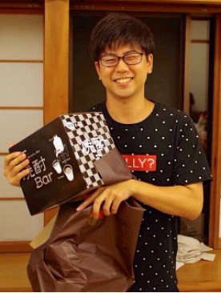

懇親会の様子

[figure not shown]

ビンゴ大会豪華景品♪

[figure not shown]

ビンゴ大会豪華景品♪

[figure not shown]

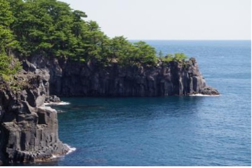

（文責・経済学科３年・安部春花 法律政治学科３年・高泉芹菜）

#### 法律政治学科1年 矢嶋亜優佳

春合宿に続き参加させていただきました。先輩方の卒論中間発表の完成度の高さ、レベルの高さに驚きを感じたと共にこれからの勉学に対して大きな刺激となりました。また、先輩方のいる中でのビブリオバトルは今までに感じたことのない緊張と不安でいっぱいでしたが、人前で話すことが苦手な私にとって、大変貴重な経験になりました。そして、前回の合宿ではお話出来なかった方ともお話出来たことや先輩方の新たな一面を見ることが出来たりと、とても充実した時間を過ごさせていただきました。今回の合宿に参加出来て本当に良かったですし、得たことを糧にこれから頑張っていきたいと思います。

#### 経済学科2年 松江大輝

自分は今回のゼミ合宿で、本当に有意義な二日間を過ごすことができました。まず、伊豆高原はとても自然豊かで、美味しい空気に、心地よい温泉と、とても最高な場所でした。宿舎のご飯もとても美味しかったです。  
実は、自分はゼミの合宿に参加する前はとても不安でした。先輩方の発表を理解することができるのだろうか、自分の発表はうまく相手に伝えることができるだろうか、と様々な不安がありました。しかし、先輩方の発表はとても丁寧で、びっくりするぐらいにわかりやすくて、また、わからないところも質問できて、それもしっかりと答えてくれて、そんな先輩方に憧れをも抱きました。また、自分の発表もちゃんと伝わるか不安でしたが、先輩方や仲間のゼミ生達がしっかり理解してくれたのでとても嬉しかったです。また、人見知りの自分に先輩方は優しく話かけてくれました。些細なことですが、本当に嬉しかったです。この、ゼミ合宿を通じて、ためになったことはもちろんのこと、人との繋がりの大切さも改めて実感することができました。

#### 法律政治学科3年 釜谷茉里

伊豆高原のルネッサ赤沢という所に、2泊3日で浅野ゼミ夏合宿に参加してきました。今年から浅野ゼミに入った私は夏合宿に参加するのは初めてでしたが、短いなかでもとても実りある合宿になったと思います。

合宿内容は、エニグラムの講義や4年生と3年生の論文発表、1年生と2年生のビブリオバトルなど様々でしたが、全体を通して私が一番感じた事は、人に自分の考えをしっかりと伝える事の難しさです。自分の頭の中ではイメージがあるので、つい他人も同じイメージを持っていると思って話しがちですが、一度自分の頭の中をしっかりと整理し、何を一番伝えたくて、どんな言葉を使えば皆に伝わるのかを日々考えてトレーニングする必要があるのだと実感しました。この力がついてくれば、今後取り組む論文も、よりシンプルで分かりやすいものになると思うので、後期も気持ちを新たに集中してゼミの勉強に取り組んでいこうと思いました。

#### 法律政治学科4年 北島啓喜

この度の浅野ゼミナール夏合宿は大変有意義でした。まず、四年生の卒業論文の中間発表です。四年の私は女性の県議会議員について統計を用いた研究を発表したのですが、当初に想定したような結果を出すことができませんでした。しかし、発表を通して今まで気づくことができなかった勘違いを見つけることができました。また、先生や同期からの活発な質疑応答や、後輩の新しい目線からの質問により、自分だけでは見つけることのできなかった問題や、新たな問題への切り口を発見することができました。これにより、卒業論文作成へ進展する一歩を踏み出すことができると確信しました。  
次に後輩たちの発表です。三年生のグループ発表は驚くものばかりでした。特に国民年金保険料納付率と格差を表すジニ係数の因果関係を調べた山本、釜谷、安藤のチームは我々四年生の発表よりも勝るとも劣らないできであり、我々四年生は良い刺激になりました。  
最後に、一、二年生のビブリオバトルと実行委員である三年が主体となり行われたレクリエーションです。ビブリオバトルではしっかりと本の内容をまとめており、彼ら自身の言葉でプレゼンしていました。そのおかげで、大変興味深い本に出会うことができました。そしてレクリエーションでは普段はキャンパスが離れ、接点のあまりない二年生と仲良くなることができました。この度の夏合宿を通し、一層の研究に励む所存です。